# Visualizing the Inequitable Incarceration of Black Men across America

Julia Kharchenko

2022-11-21

## Abstract

Throughout this project, we will be comparing the incarceration of Black men with the incarceration of men from other races, attempting to demonstrate the structural oppression that Black men face within the American legal system.

## Introduction

After the end of slavery and segregation across the United States and the passage of the Civil Rights Act, many believe that structural racism in America is long gone. However, this couldn’t be farther from the truth - the current incarceration system within the United States was built off of racism and continues to carry its tenets to the modern day, disproportionately impacting Black men and furthering institutional racism across the nation. While many do not believe this, they have not had the facts of racial discrimination presented to them clearly - which is exactly what this project will do. We will be attempting to answer the question, “How does the incarceration of Black men vary from the incarceration of other races across the United States, both in the current day and historically?” By answering this question and undergoing this project, we will be directly impacting those who are incarcerated or at risk of being incarcerated, primarily Black men in America (direct stakeholders), by presenting the facts of their incarceration so we can truly show the injustice. Our indirect stakeholders will be ordinary Americans, especially those currently holding some form of responsibility in the legal system, so that we can present the true facts of racism to them and inspire them to make change within the American legal/incarceration system.

## Data Summary

I decided to analyze three different variables related to my goals: the year with the highest number of Black Americans in jail, the average population rate of Black Americans in jail in the highest incarceration year across counties, and the average percentage of Black Americans in jail compared to the total Black population per county across counties. The year with the highest number of Black Americans in jail is important to know because if it is the current year, then I know this problem has been persisting and continues to be of grave concern to the modern day and if it is some year in the past, then that year had a lot of racial tension/racism associated with it. Since the year with the highest number of Black Americans in jail is 2018, the most recent year in the dataset, then I know that Black Americans keep getting incarcerated in jail at higher populations as years go by, pointing to a systemic problem. I wanted to understand the average population rate of Black Americans in jail in the highest incarceration year (being the most recent year) across counties to determine how the incarceration of Black Americans was continuously growing throughout many years and whether it was alarming. Given that it was 2519.287, I know that the growth in Black Americans being incarcerated is highly troubling and leads me to believe that there are systemic issues that must be dismantled. Finally, I wanted to understand the average percentage of Black Americans in jail compared to the total Black population per county across counties to see what proportion of the Black population in each county is behind bars, and whether that points to racist implications in our legal system. Given that 0.02519287, or ~2.5% of the Black population is behind bars in each county on average, we know that there is systematic oppression in our legal system because that is a concerningly large percentage.

## Growth of the U.S. Prison Population

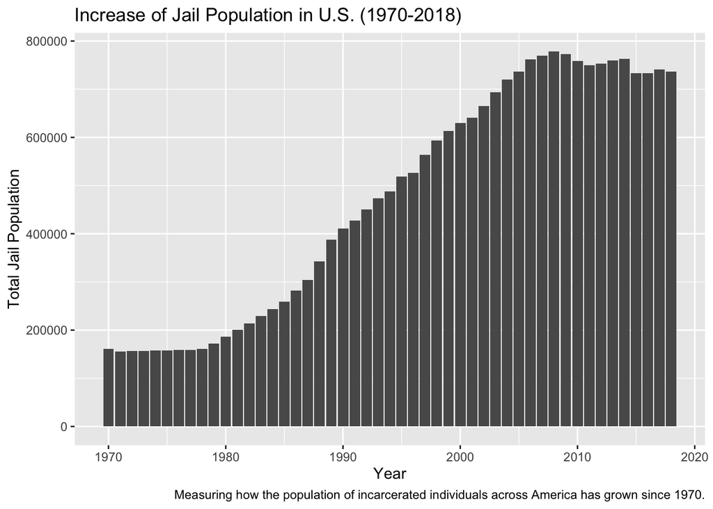

When creating this visualization, I wanted to answer the question, “How has the population of incarcerated individuals across America grown since 1970?” Throughout this chart, we can see that from the 1970s-1980s, the population of incarcerated individuals in America was relatively steady at less than 200,000 individuals and even on a slight decline at times. However, since the 1980s, the population of incarcerated individuals in America has seemingly skyrocketed up until the 2010s, where it has slowly been leveling off/slightly decreasing; some policies that contribute to further oppression may have been at play in the 1980s. Yet it still begs the questions, what is contributing to the growing incarceration rate in the United States, and is this trend common within every state in the U.S.?

## Growth of Prison Population By State

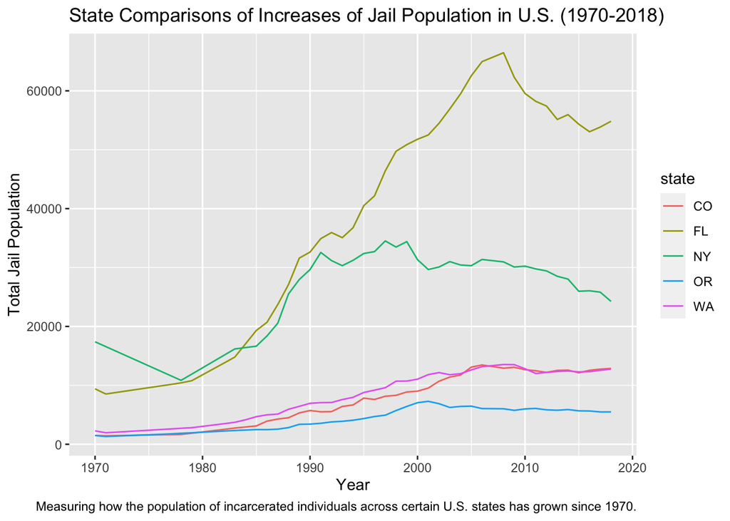

## Comparing Incarceration Populations Across Racial Backgrounds

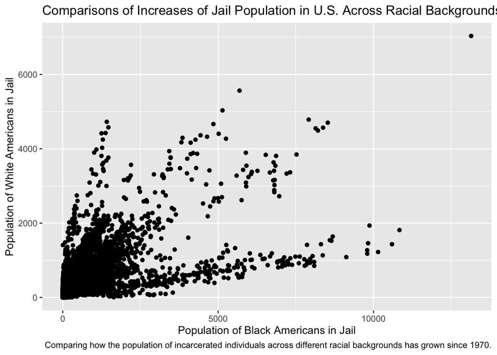

When creating this chart, I wanted to answer the question, “how does the incarceration population of Black Americans compare to that of White Americans?” and thus created a scatterplot to compare the population of both groups in jail. I can see that the population of Black Americans in jail is much more varied and reaches a greater extent than that of White Americans, which is quite shocking given the population gap between the two races. Thus, it can be interpreted that White Americans tend to get incarcerated at very minimal rates which Black Americans tend to get incarcerated at a greater variety of rates and tend to have a larger incarcerated population than White Americans (for example, when there are ~10000 incarcerated Black Americans, there are only ~2000 incarcerated White Americans, which is a big discrepancy given their population differences that can be explained by addressing institutional racism).

## Visualizing the Average Percentage of Incarcerated Black Citizens Across the Entire Country

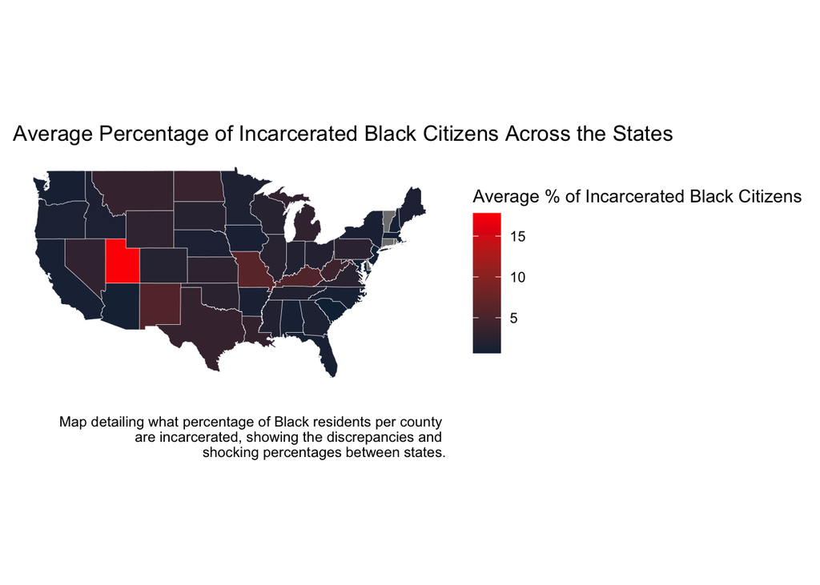